# BST 270 individual project: Bad Drivers

William Nickols

willnickols@g.harvard.edu

#### Motivations and Reproducibility

This repository reproduces the figures from FiveThirtyEight’s [Dear Mona, Which State Has The Worst Drivers?](https://fivethirtyeight.com/features/which-state-has-the-worst-drivers/). Doing so will utilize data from the National Highway Traffic Safety Administration (2009, 2012) and National Association of Insurance Commissioners (2010, 2011).

## Setup

The package can be installed as described in the README:

```
if (!require("devtools", quietly = TRUE))
    install.packages("devtools")

devtools::install_github("WillNickols/bst270-project", build_vignettes = TRUE,
    force = TRUE, dependencies = TRUE)
browseVignettes('bst270')
```

The following code loads the required packages and reads the data in from this package’s source.

```r
suppressPackageStartupMessages(library(ggplot2))
suppressPackageStartupMessages(library(dplyr))
library(bst270)

dataset <- read.csv(system.file(package="bst270","extdata","bad-drivers.csv"))
```

## Reproducing Plots

### Figure 1: Distracted drivers

The following code reproduces the first figure from the article. Since the original data contain the number of fatal collisions per billion miles and the proportion of those from distracted drivers, the code divides the number of fatal collisions per billion miles into those with distracted drivers and those without distracted drivers and plots a stacked bar plot.

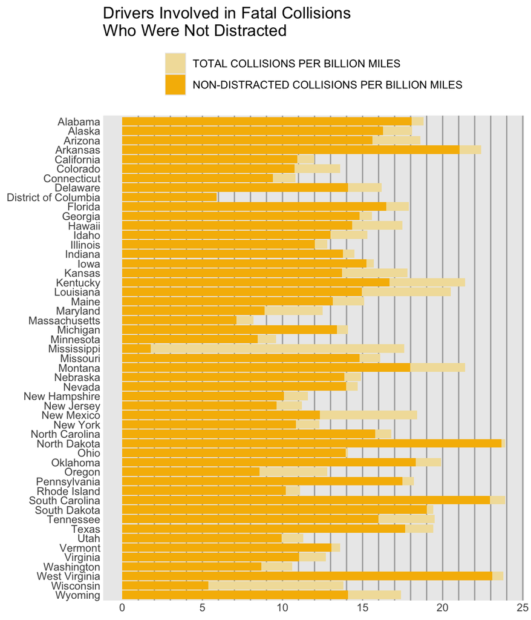

```r
# Create a data frame with the number of fatal collisions for
# nondistracted and distracted drivers per state.
fig1_df <- dataset %>%
    mutate(nondistracted = Number.of.drivers.involved.in.fatal.collisions.per.billion.miles *
               (Percentage.Of.Drivers.Involved.In.Fatal.Collisions.Who.Were.Not.Distracted / 100),
           distracted = Number.of.drivers.involved.in.fatal.collisions.per.billion.miles *
               (1 - Percentage.Of.Drivers.Involved.In.Fatal.Collisions.Who.Were.Not.Distracted / 100),
           State = factor(State, rev(State))) %>%
    select(State, nondistracted, distracted) %>%
    reshape2::melt(id.vars = "State") %>% # Turn into long data
    mutate(variable = case_when(variable == 'distracted' ~ "TOTAL COLLISIONS PER BILLION MILES",
                                variable == 'nondistracted' ~ "NON-DISTRACTED COLLISIONS PER BILLION MILES")) %>%
    mutate(variable = factor(variable, levels = c("TOTAL COLLISIONS PER BILLION MILES",
                                                  "NON-DISTRACTED COLLISIONS PER BILLION MILES")))

# Reproduce figure 1 using a stacked bar plot
ggplot(fig1_df, aes(x = State, y = value, fill = variable)) +
    geom_bar(position = "stack", stat = "identity") +
    scale_fill_manual(values = c("NON-DISTRACTED COLLISIONS PER BILLION MILES" = "#f6b900",
                                "TOTAL COLLISIONS PER BILLION MILES" = "#f2dfa8")) +
    ggtitle('Drivers Involved in Fatal Collisions\nWho Were Not Distracted') +
    theme(
        axis.title = element_blank(),
        legend.title = element_blank(),
        legend.position = 'top',
        legend.direction = 'vertical',
        panel.grid.major.y = element_line(color = "darkgray"),
        panel.grid.major.x = element_blank(),
        panel.grid.minor = element_blank(),
        axis.ticks = element_blank()
    ) +
    coord_flip()
```

### Figure 2: Drivers without previous accidents

The following code reproduces the second figure from the article. Since the original data contain the number of fatal collisions per billion miles and the proportion of those with previous accidents, the code divides the number of fatal collisions per billion miles into those with a driver who had been in a previous accident and those without a driver who had been in a previous accident.

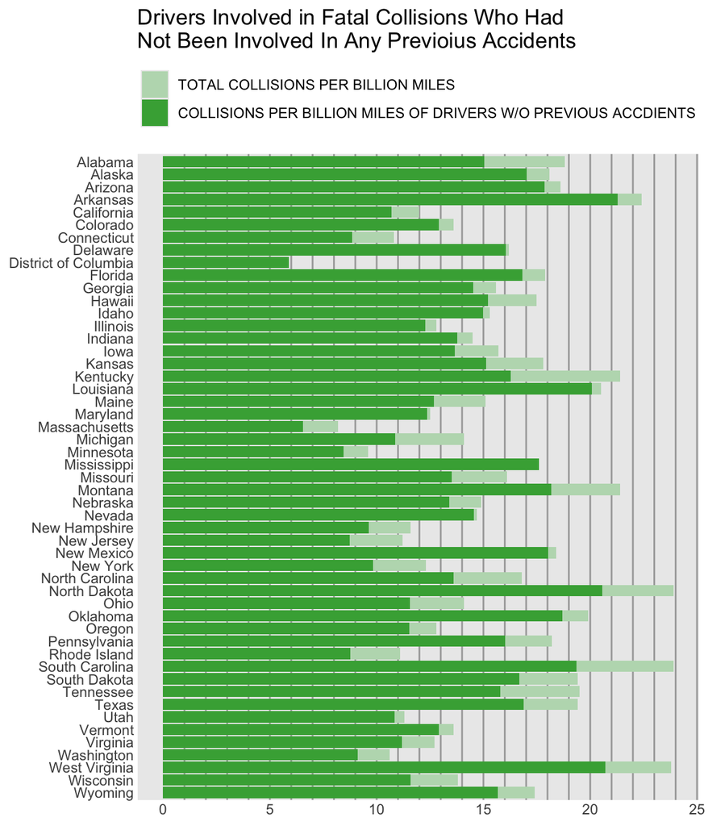

```r
# Create a data frame with the number of fatal collisions for
# first-accident and not-first-accident drivers per state.
fig2_df <- dataset %>%
    mutate(new = Number.of.drivers.involved.in.fatal.collisions.per.billion.miles *
               (Percentage.Of.Drivers.Involved.In.Fatal.Collisions.Who.Had.Not.Been.Involved.In.Any.Previous.Accidents / 100),
           old = Number.of.drivers.involved.in.fatal.collisions.per.billion.miles *
               (1 - Percentage.Of.Drivers.Involved.In.Fatal.Collisions.Who.Had.Not.Been.Involved.In.Any.Previous.Accidents / 100),
           State = factor(State, rev(State))) %>%
    select(State, new, old) %>%
    reshape2::melt(id.vars = "State") %>%
    mutate(variable = case_when(variable == 'old' ~ "TOTAL COLLISIONS PER BILLION MILES",
                                variable == 'new' ~ "COLLISIONS PER BILLION MILES OF DRIVERS W/O PREVIOUS ACCDIENTS")) %>%
    mutate(variable = factor(variable, levels = c("TOTAL COLLISIONS PER BILLION MILES",
                                                  "COLLISIONS PER BILLION MILES OF DRIVERS W/O PREVIOUS ACCDIENTS")))

ggplot(fig2_df, aes(x = State, y = value, fill = variable)) +
    geom_bar(position = "stack", stat = "identity") +
    scale_fill_manual(values = c("COLLISIONS PER BILLION MILES OF DRIVERS W/O PREVIOUS ACCDIENTS" = "#44ab43",
                                "TOTAL COLLISIONS PER BILLION MILES" = "#bcdbbc")) +
    ggtitle('Drivers Involved in Fatal Collisions Who Had\nNot Been Involved In Any Previoius Accidents') +
    theme(
        axis.title = element_blank(),
        legend.title = element_blank(),
        legend.position = 'top',
        legend.direction = 'vertical',
        panel.grid.major.y = element_line(color = "darkgray"),
        panel.grid.major.x = element_blank(),
        panel.grid.minor = element_blank(),
        axis.ticks = element_blank()
    ) +
    coord_flip()
```